# LESSON 5: MATPLOTLIB INTRODUCTION

[figure not shown]

## 1. Overall introduction

Matplotlib is an open-source Python library for data visualization.  
Matplotlib is the whole package. And it contains 2 modules: `pylab` and `pyplot`.

- `pyplot` provides the state-machine interface for plotting. That means, each line of code change the state of plotting.
- `pylab` can be said as the combination of `numpy` functionality and `pyplot` functionality.

## 2. Install and import libraries

Install matplotlib by running this command in jupyter notebook: `!conda install -c conda-forge matplotlib -y`

```python
import matplotlib.pyplot as plt
import numpy as np
```

## 3. Simple plots

### 3.1. Line plot

#### Show single line plot and multiple line plots

```python
x = np.linspace(-5, 5, 50)
x
```

```
array([-5.        , -4.79591837, -4.59183673, -4.3877551 , -4.18367347,
       -3.97959184, -3.7755102 , -3.57142857, -3.36734694, -3.16326531,
       -2.95918367, -2.75510204, -2.55102041, -2.34693878, -2.14285714,
       -1.93877551, -1.73469388, -1.53061224, -1.32653061, -1.12244898,
       -0.91836735, -0.71428571, -0.51020408, -0.30612245, -0.10204082,
        0.10204082,  0.30612245,  0.51020408,  0.71428571,  0.91836735,
        1.12244898,  1.32653061,  1.53061224,  1.73469388,  1.93877551,
        2.14285714,  2.34693878,  2.55102041,  2.75510204,  2.95918367,
        3.16326531,  3.36734694,  3.57142857,  3.7755102 ,  3.97959184,
        4.18367347,  4.3877551 ,  4.59183673,  4.79591837,  5.        ])
```

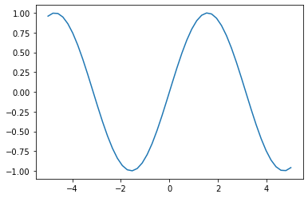

```python
# single line plot
plt.plot(x, np.sin(x)) # plt.plot(x, y)
plt.show()
```

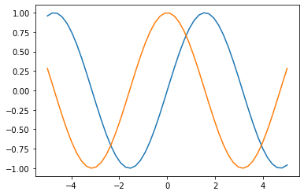

```python
# multiple line plots in multiple lines of code
plt.plot(x, np.sin(x))
plt.plot(x, np.cos(x))
plt.show()
```

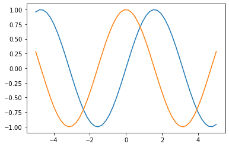

```python
# multiple lines plot in single line of code
plt.plot(x, np.sin(x), x, np.cos(x)) # plt.plot(x1, y1, x2, y2)
plt.show()
```

#### Change Marker format

##### Change marker shape by `marker`

List of marker shapes [here](https://matplotlib.org/stable/api/markers_api.html)

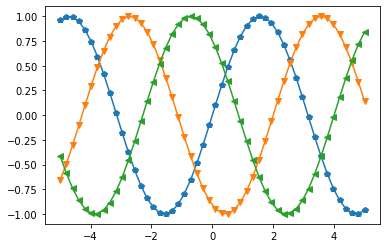

```python
plt.plot(x, np.sin(x - 0), marker='p')
plt.plot(x, np.sin(x - 2), marker='v')
plt.plot(x, np.sin(x - 4), marker='<')
plt.show()
```

##### Change marker size by `markersize` or `ms`

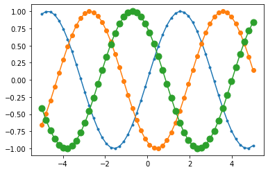

```python
# Using `markersize`
plt.plot(x, np.sin(x - 0), marker='o', markersize=3)
plt.plot(x, np.sin(x - 2), marker='o', markersize=6)
plt.plot(x, np.sin(x - 4), marker='o', markersize=9)
plt.show()
```

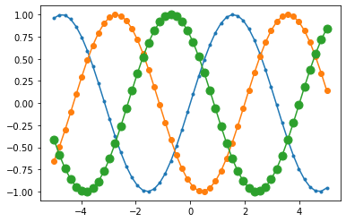

```python
# Using `ms`
plt.plot(x, np.sin(x - 0), marker='o', ms=3)
plt.plot(x, np.sin(x - 2), marker='o', ms=6)
plt.plot(x, np.sin(x - 4), marker='o', ms=9)
plt.show()
```

##### Change marker edge color by `markeredgecolor` or `mec`

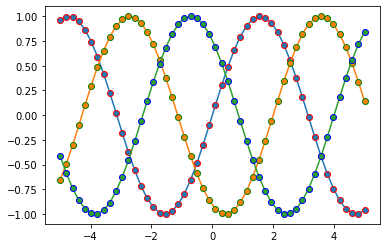

```python
# Using `markeredgecolor`
plt.plot(x, np.sin(x - 0), marker='o', markeredgecolor='r')
plt.plot(x, np.sin(x - 2), marker='o', markeredgecolor='g')
plt.plot(x, np.sin(x - 4), marker='o', markeredgecolor='b')
plt.show()
```

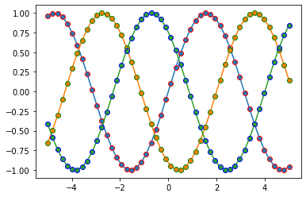

```python
# Using `mec`
plt.plot(x, np.sin(x - 0), marker='o', mec='r')
plt.plot(x, np.sin(x - 2), marker='o', mec='g')
plt.plot(x, np.sin(x - 4), marker='o', mec='b')
plt.show()
```

##### Change marker face color by `markerfacecolor` or `mfc`

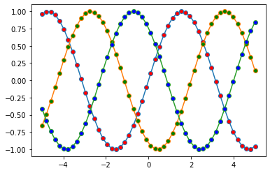

```python
# Using `markerfacecolor`
plt.plot(x, np.sin(x - 0), marker='o', markerfacecolor='r')
plt.plot(x, np.sin(x - 2), marker='o', markerfacecolor='g')
plt.plot(x, np.sin(x - 4), marker='o', markerfacecolor='b')
plt.show()
```

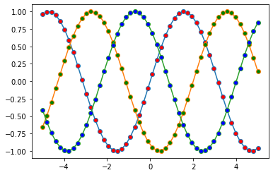

```python
# Using `mfc`
plt.plot(x, np.sin(x - 0), marker='o', mfc='r')
plt.plot(x, np.sin(x - 2), marker='o', mfc='g')
plt.plot(x, np.sin(x - 4), marker='o', mfc='b')
plt.show()
```

#### Change line color by `color` or `c`

List of colors [here](https://matplotlib.org/stable/tutorials/colors/colors.html)

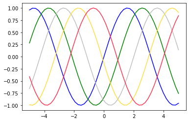

```python
# Using `color`
plt.plot(x, np.sin(x - 0), color='blue')        # Color by name
plt.plot(x, np.sin(x - 1), color='g')           # Color by shortname
plt.plot(x, np.sin(x - 2), color='0.75')        # Grayscale between 0 and 1
plt.plot(x, np.sin(x - 3), color='#FFDD44')     # Hex code (RRGGBB from 00 to FF)
plt.plot(x, np.sin(x - 4), color=(1.0,0.2,0.3)) # RGB tuple, values 0 to 1
plt.show()
```

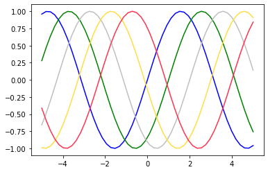

```python
# Using `c`
plt.plot(x, np.sin(x - 0), c='blue')        # Color by name
plt.plot(x, np.sin(x - 1), c='g')           # Color by shortname
plt.plot(x, np.sin(x - 2), c='0.75')        # Grayscale between 0 and 1
plt.plot(x, np.sin(x - 3), c='#FFDD44')     # Hex code (RRGGBB from 00 to FF)
plt.plot(x, np.sin(x - 4), c=(1.0,0.2,0.3)) # RGB tuple, values 0 to 1
plt.show()
```

#### Change line style by `linestyle` or `ls`

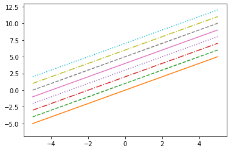

```python
# Using `linestyle`
plt.plot(x, x - 1, linestyle='None')
plt.plot(x, x + 0, linestyle='solid')
plt.plot(x, x + 1, linestyle='dashed')
plt.plot(x, x + 2, linestyle='dashdot')
plt.plot(x, x + 3, linestyle='dotted')

plt.plot(x, x - 1, linestyle='')
plt.plot(x, x + 4, linestyle='-')  # solid
plt.plot(x, x + 5, linestyle='--') # dashed
plt.plot(x, x + 6, linestyle='-.') # dashdot
plt.plot(x, x + 7, linestyle=':')  # dotted
plt.show()
```

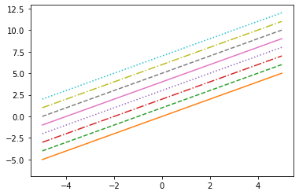

```python
# Using `ls`
plt.plot(x, x - 1, ls='None')
plt.plot(x, x + 0, ls='solid')
plt.plot(x, x + 1, ls='dashed')
plt.plot(x, x + 2, ls='dashdot')
plt.plot(x, x + 3, ls='dotted')

plt.plot(x, x - 1, ls='')   # None
plt.plot(x, x + 4, ls='-')  # solid
plt.plot(x, x + 5, ls='--') # dashed
plt.plot(x, x + 6, ls='-.') # dashdot
plt.plot(x, x + 7, ls=':')  # dotted
plt.show()
```

#### Change line width by `linewidth` or `lw`

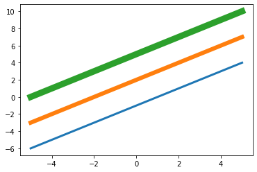

```python
# Using `linewidth`
plt.plot(x, x - 1, linewidth='3')
plt.plot(x, x + 2, linewidth='6')
plt.plot(x, x + 5, linewidth='9')
plt.show()
```

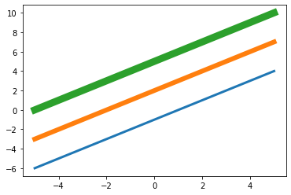

```python
# Using `lw`
plt.plot(x, x - 1, lw='3')
plt.plot(x, x + 2, lw='6')
plt.plot(x, x + 5, lw='9')
plt.show()
```

#### Change line format by Format String

Format String = `'[marker][line][color]'`

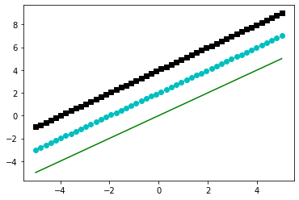

```python
plt.plot(x, x + 0, '-g')    # [no marker][solid][green]
plt.plot(x, x + 2, 'o--c')  # [circle][dashed][cyan]
plt.plot(x, x + 4, 's-.k')  # [square][dashdot][black]
plt.show()
```

### 3.2. Scatter plot

#### Show single scatter plot and multiple scatter plots

```python
x = np.random.randint(1, 100, size=50)
y = np.random.randint(1, 100, size=50)
```

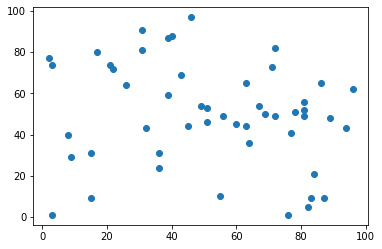

```python
# single scatter plot
plt.scatter(x, y)
plt.show()
```

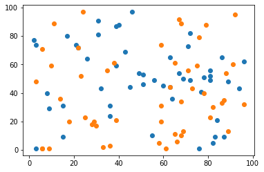

```python
# multiple scatter plots
xx = np.random.randint(1, 100, size=50)
yy = np.random.randint(1, 100, size=50)

plt.scatter(x, y)
plt.scatter(xx, yy)
plt.show()
```

#### Change scatter color by `color` or `c`

List of colors [here](https://matplotlib.org/stable/tutorials/colors/colors.html)

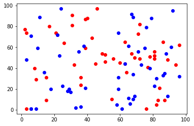

```python
plt.scatter(x, y, color='r')
plt.scatter(xx, yy, color='b')
plt.show()
```

#### Change scatter color map

List of color map style [here](https://matplotlib.org/stable/tutorials/colors/colormaps.html)

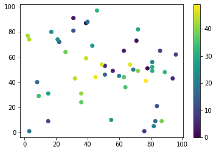

```python
color_map = np.arange(50)

plt.scatter(x, y, c=color_map, cmap='viridis')
plt.colorbar()
plt.show()
```

#### Bubble plot

Bubble plot is Scatter plot with multiple sizes of scatter

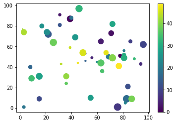

```python
color_map = np.arange(50)
bubble_size = np.random.randint(1, 200, size=50)

plt.scatter(x, y, s=bubble_size, c=color_map, cmap='viridis')
plt.colorbar()
plt.show()
```

### 3.3. Stack plot

```python
category = ['category 1', 'category 2', 'category 3', 'category 4', 'category 5']
index = np.arange(5)
value_1 = np.random.randint(10, 50, size=5)
value_2 = np.random.randint(10, 50, size=5)
value_3 = np.random.randint(10, 50, size=5)
```

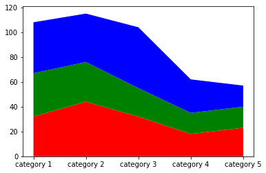

```python
plt.stackplot(category, value_1, value_2, value_3, colors=['r', 'g', 'b'])
plt.show()
```

### 3.4. Bar plot

#### Show single bar plot

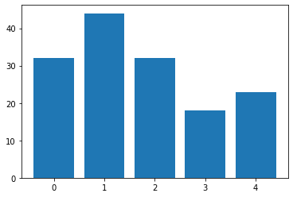

```python
plt.bar(index, value_1)
plt.show()
```

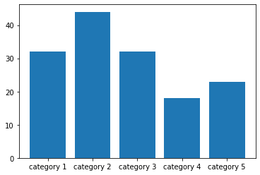

```python
plt.bar(category, value_1)
plt.show()
```

#### Show horizontal bar plot

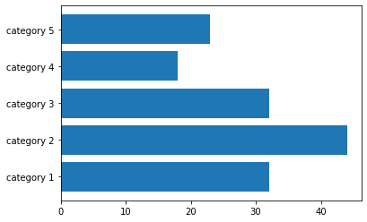

```python
plt.barh(category, value_1)
plt.show()
```

#### Change bar color

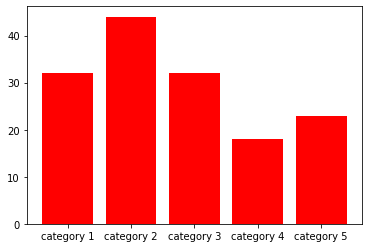

```python
plt.bar(category, value_1, color='r')
plt.show()
```

#### Change bar size

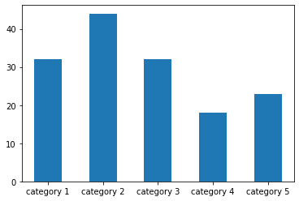

```python
# Change vetical bar width
plt.bar(category, value_1, width=0.5)
plt.show()
```

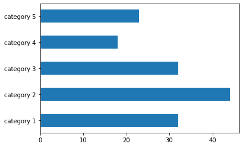

```python
# Change horizontal bar height
plt.barh(category, value_1, height=0.5)
plt.show()
```